# Linear Regression Example

Jeff Bostwick

11/10/2020

## Load Packages and Explore Data

Loading Packages

```r
library(sjPlot)
library(dplyr)
library(sjlabelled)
library(sjmisc)
library(ggplot2)
theme_set(theme_sjplot())
```

Loading Dataset

Previewing the Dataset

```r
head(data)
```

```
##   Make      Model Year            Engine.Fuel.Type Engine.HP Engine.Cylinders
## 1  BMW 1 Series M 2011 premium unleaded (required)       335                6
## 2  BMW   1 Series 2011 premium unleaded (required)       300                6
## 3  BMW   1 Series 2011 premium unleaded (required)       300                6
## 4  BMW   1 Series 2011 premium unleaded (required)       230                6
## 5  BMW   1 Series 2011 premium unleaded (required)       230                6
## 6  BMW   1 Series 2012 premium unleaded (required)       230                6
##   Transmission.Type    Driven_Wheels Number.of.Doors
## 1            MANUAL rear wheel drive               2
## 2            MANUAL rear wheel drive               2
## 3            MANUAL rear wheel drive               2
## 4            MANUAL rear wheel drive               2
## 5            MANUAL rear wheel drive               2
## 6            MANUAL rear wheel drive               2
##                         Market.Category Vehicle.Size Vehicle.Style highway.MPG
## 1 Factory Tuner,Luxury,High-Performance      Compact         Coupe          26
## 2                    Luxury,Performance      Compact   Convertible          28
## 3               Luxury,High-Performance      Compact         Coupe          28
## 4                    Luxury,Performance      Compact         Coupe          28
## 5                                Luxury      Compact   Convertible          28
## 6                    Luxury,Performance      Compact         Coupe          28
##   city.mpg Popularity  MSRP
## 1       19       3916 46135
## 2       19       3916 40650
## 3       20       3916 36350
## 4       18       3916 29450
## 5       18       3916 34500
## 6       18       3916 31200
```

Viewing the Structure of the Dataset

```r
str(data)
```

```
## 'data.frame':    11914 obs. of  16 variables:
##  $ Make             : chr  "BMW" "BMW" "BMW" "BMW" ...
##  $ Model            : chr  "1 Series M" "1 Series" "1 Series" "1 Series" ...
##  $ Year             : int  2011 2011 2011 2011 2011 2012 2012 2012 2012 2013 ...
##  $ Engine.Fuel.Type : chr  "premium unleaded (required)" "premium unleaded (required)" "premium unleaded (required)" "premium unleaded (required)" ...
##  $ Engine.HP        : int  335 300 300 230 230 230 300 300 230 230 ...
##  $ Engine.Cylinders : int  6 6 6 6 6 6 6 6 6 6 ...
##  $ Transmission.Type: chr  "MANUAL" "MANUAL" "MANUAL" "MANUAL" ...
##  $ Driven_Wheels    : chr  "rear wheel drive" "rear wheel drive" "rear wheel drive" "rear wheel drive" ...
##  $ Number.of.Doors  : int  2 2 2 2 2 2 2 2 2 2 ...
##  $ Market.Category  : chr  "Factory Tuner,Luxury,High-Performance" "Luxury,Performance" "Luxury,High-Performance" "Luxury,Performance" ...
##  $ Vehicle.Size     : chr  "Compact" "Compact" "Compact" "Compact" ...
##  $ Vehicle.Style    : chr  "Coupe" "Convertible" "Coupe" "Coupe" ...
##  $ highway.MPG      : int  26 28 28 28 28 28 26 28 28 27 ...
##  $ city.mpg         : int  19 19 20 18 18 18 17 20 18 18 ...
##  $ Popularity       : int  3916 3916 3916 3916 3916 3916 3916 3916 3916 3916 ...
##  $ MSRP             : int  46135 40650 36350 29450 34500 31200 44100 39300 36900 37200 ...
```

Summary of the Dataset

```r
summary(data)
```

```
##      Make              Model                Year      Engine.Fuel.Type
##  Length:11914       Length:11914       Min.   :1990   Length:11914
##  Class :character   Class :character   1st Qu.:2007   Class :character
##  Mode  :character   Mode  :character   Median :2015   Mode  :character
##                                        Mean   :2010
##                                        3rd Qu.:2016
##                                        Max.   :2017
##
##    Engine.HP      Engine.Cylinders Transmission.Type  Driven_Wheels
##  Min.   :  55.0   Min.   : 0.000   Length:11914       Length:11914
##  1st Qu.: 170.0   1st Qu.: 4.000   Class :character   Class :character
##  Median : 227.0   Median : 6.000   Mode  :character   Mode  :character
##  Mean   : 249.4   Mean   : 5.629
##  3rd Qu.: 300.0   3rd Qu.: 6.000
##  Max.   :1001.0   Max.   :16.000
##  NA's   :69       NA's   :30
##  Number.of.Doors Market.Category    Vehicle.Size       Vehicle.Style
##  Min.   :2.000   Length:11914       Length:11914       Length:11914
##  1st Qu.:2.000   Class :character   Class :character   Class :character
##  Median :4.000   Mode  :character   Mode  :character   Mode  :character
##  Mean   :3.436
##  3rd Qu.:4.000
##  Max.   :4.000
##  NA's   :6
##   highway.MPG        city.mpg        Popularity        MSRP
##  Min.   : 12.00   Min.   :  7.00   Min.   :   2   Min.   :   2000
##  1st Qu.: 22.00   1st Qu.: 16.00   1st Qu.: 549   1st Qu.:  21000
##  Median : 26.00   Median : 18.00   Median :1385   Median :  29995
##  Mean   : 26.64   Mean   : 19.73   Mean   :1555   Mean   :  40595
##  3rd Qu.: 30.00   3rd Qu.: 22.00   3rd Qu.:2009   3rd Qu.:  42231
##  Max.   :354.00   Max.   :137.00   Max.   :5657   Max.   :2065902
##
```

## Task 2 - Clean your dataset

Capture all columns that are character fields

```r
cols <- names(data)[vapply(data, is.character, logical(1))]
data[,cols] <- lapply(data[,cols],trimws)
```

Convert missing values to NAs

```r
data[data=="N/A"] = NA
```

Use sapply(), which is like a for loop that goes through each column of the dataset and applys the function to it

```r
sapply(data, function(x) mean(is.na(x)))
```

```
##              Make             Model              Year  Engine.Fuel.Type
##      0.0000000000      0.0000000000      0.0000000000      0.0000000000
##         Engine.HP  Engine.Cylinders Transmission.Type     Driven_Wheels
##      0.0057915058      0.0025180460      0.0000000000      0.0000000000
##   Number.of.Doors   Market.Category      Vehicle.Size     Vehicle.Style
##      0.0005036092      0.3140842706      0.0000000000      0.0000000000
##       highway.MPG          city.mpg        Popularity              MSRP
##      0.0000000000      0.0000000000      0.0000000000      0.0000000000
```

It looks like Market.Category column has a high number of missing values (roughly 31.4%) It might be smart to remove this column from the dataset by running the code below

```r
data$Market.Category <- NULL
```

Return only observations that have no missing values and preview the dataset

```r
data <- data[complete.cases(data),]
head(data)
```

```
##   Make      Model Year            Engine.Fuel.Type Engine.HP Engine.Cylinders
## 1  BMW 1 Series M 2011 premium unleaded (required)       335                6
## 2  BMW   1 Series 2011 premium unleaded (required)       300                6
## 3  BMW   1 Series 2011 premium unleaded (required)       300                6
## 4  BMW   1 Series 2011 premium unleaded (required)       230                6
## 5  BMW   1 Series 2011 premium unleaded (required)       230                6
## 6  BMW   1 Series 2012 premium unleaded (required)       230                6
##   Transmission.Type    Driven_Wheels Number.of.Doors Vehicle.Size Vehicle.Style
## 1            MANUAL rear wheel drive               2      Compact         Coupe
## 2            MANUAL rear wheel drive               2      Compact   Convertible
## 3            MANUAL rear wheel drive               2      Compact         Coupe
## 4            MANUAL rear wheel drive               2      Compact         Coupe
## 5            MANUAL rear wheel drive               2      Compact   Convertible
## 6            MANUAL rear wheel drive               2      Compact         Coupe
##   highway.MPG city.mpg Popularity  MSRP
## 1          26       19       3916 46135
## 2          28       19       3916 40650
## 3          28       20       3916 36350
## 4          28       18       3916 29450
## 5          28       18       3916 34500
## 6          28       18       3916 31200
```

## Task 3 - Split into training and test set

Now we will only be selecting numeric columns from the dataset for our linear regression model

```r
data_num <- data %>% select_if(is.numeric)
```

The target variable for our machine learning model is the price column (MSRP) Now we will create a histogram to see the MSRP distribution

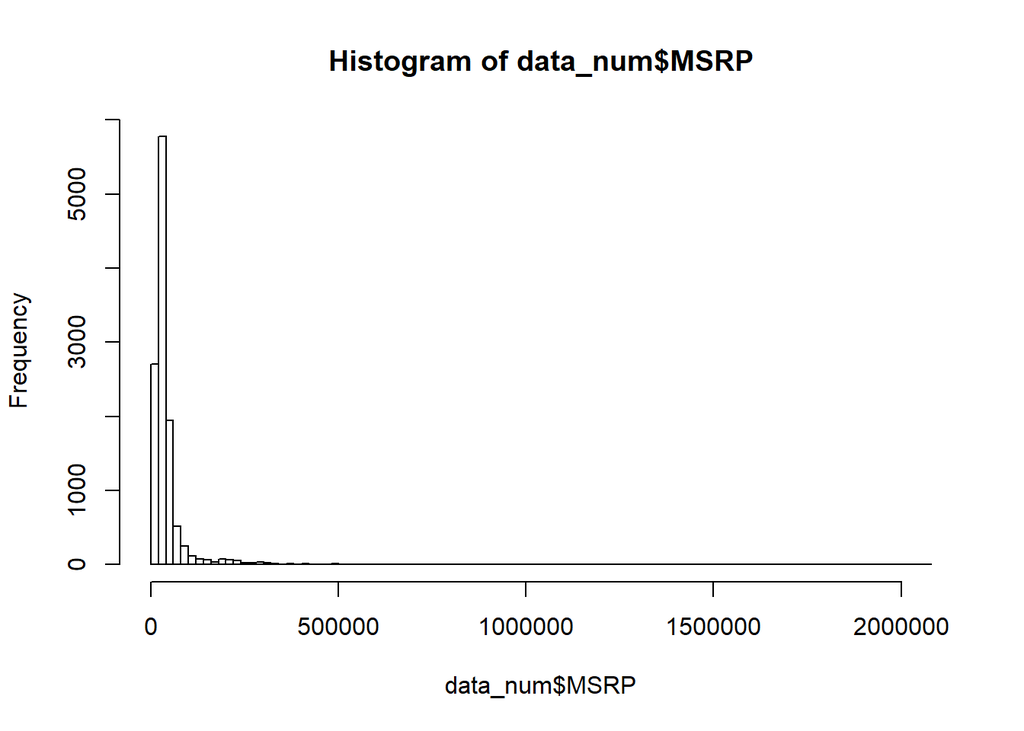

```r
hist(data_num$MSRP, breaks=100)
```

This shows us that there are some outliers in our column as the majority of cars have the price in this region. these outliers can cause issues with the model, so we can filter the dataset to include cars with a price range of 15,000 and 50,000.

```r
data_num <- data_num %>% filter(MSRP > 15000) %>% filter(MSRP < 50000)
```

```r
set.seed(123)
size <- floor(0.8 * nrow(data_num))
```

Now we will use the sample() function to randomly select 80% of rows from your dataset and store the row numbers.

```r
train_ind <- sample(seq_len(nrow(data_num)), size = size)
```

To get the training dataset set you can filter the dataset to include the row numbers, to get the test dataset you can filter the dataset to ignore the row numbers.

```r
train <- data_num[train_ind, ]
test <- data_num[-train_ind, ]
```

## Task 4 - Fit linear regression model and interpret model summary statistics

A linear regression model is a model that assumes a linear relationship between the predictors and the response variable.

This means that the response variable can be calculated from a linear combination of predictors.

In this dataset the the response variable is the MSRP column, while the remaininag columns are the predictors.

The goals is to build a model to predict the MSRP column, by using the characteristcs such as Engine, HP, number of doors, etc.

To build the linear regression model we will use the lm() function and focus on the model equation and the dataset to be used.

The model equations can be returned in column names while the dataset we will be using will be the training dataset.

```r
model <- lm(MSRP ~ .,data = train)
summary(model)
```

```
##
## Call:
## lm(formula = MSRP ~ ., data = train)
##
## Residuals:
##      Min       1Q   Median       3Q      Max
## -18494.4  -3819.5   -717.9   3407.0  20580.3
##
## Coefficients:
##                    Estimate Std. Error t value Pr(>|t|)
## (Intercept)      -2.784e+05  4.012e+04  -6.940 4.32e-12 ***
## Year              1.430e+02  2.006e+01   7.128 1.13e-12 ***
## Engine.HP         1.121e+02  1.779e+00  63.006  < 2e-16 ***
## Engine.Cylinders -1.144e+03  9.981e+01 -11.461  < 2e-16 ***
## Number.of.Doors   3.567e+02  9.030e+01   3.950 7.91e-05 ***
## highway.MPG      -9.825e+01  2.898e+01  -3.390 0.000703 ***
## city.mpg          1.638e+02  2.544e+01   6.440 1.29e-10 ***
## Popularity       -2.279e-01  4.962e-02  -4.593 4.45e-06 ***
## ---
## Signif. codes:  0 '***' 0.001 '**' 0.01 '*' 0.05 '.' 0.1 ' ' 1
##
## Residual standard error: 5538 on 6384 degrees of freedom
## Multiple R-squared:  0.5929, Adjusted R-squared:  0.5925
## F-statistic:  1328 on 7 and 6384 DF,  p-value: < 2.2e-16
```

In the Coefficients we can see the statistical significance. Predictive variables that are significantly associated with the outcome variables are marked with stars.

The higher the amount of stars, the more significant the predictors are. For a given predictor value, the coefficient (which is called the estimate) can be interepted as the average effect on the response varable of one unit increase in predictor given that all other predictors are fixed.

The Residual Standard Error, Mult R-Squared, and F-Statistics are metrics that are used to check how well the model fits your data.

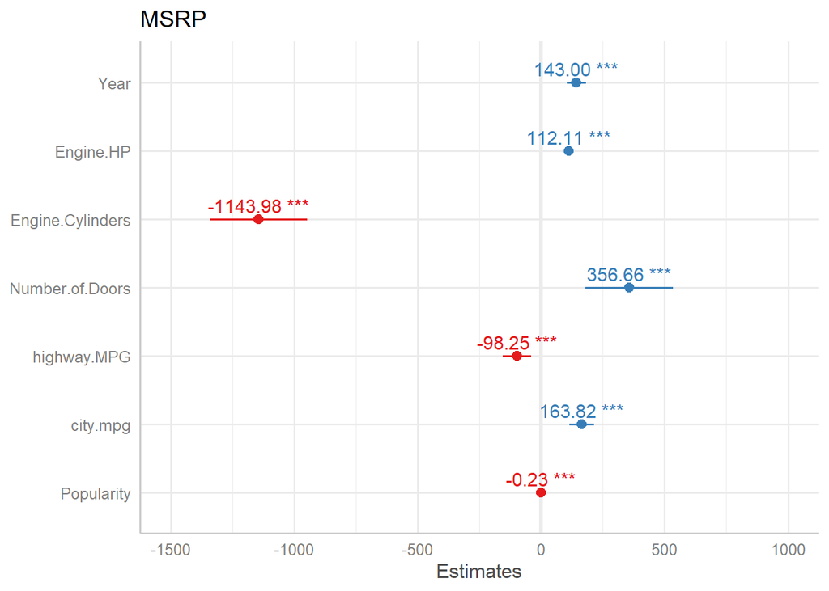

```r
plot_model(model, show.values = TRUE, value.offset = 0.2)
```

this plot shows the coefficient and significance value now you can build a linear regression model by sepcifying the predictors that you want. for examples you might want to include only 3 predictors instead all of them in you dataset

```r
model2 <- lm(MSRP ~ Engine.HP + highway.MPG + Engine.Cylinders, data = train)
```

## Task 5 - Plot and analyse model residuals

residuals can show how poorly a matter represents data. They are left over values of teh response variable after fitting a model to data, and they can reveil unexplained patterns in the data by the fitted model. Using this information, not only could we check if linear regression assumptions are met, but you could improve your model as well.

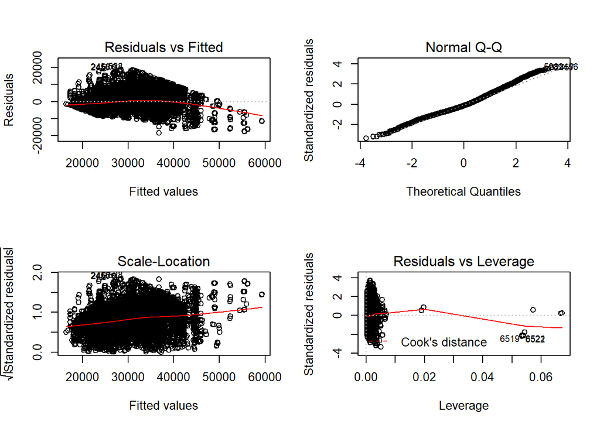

```r
par(mfrow=c(2,2))
plot(model)
```

this wil set the plotting pane to include 4 plots( 2 rows and 2 columns)

R vs Fitted show if residuals have nnn-linear patterns. fitted values are on the x axis and the residuals (which are how far the fitted values are from the observed values)are on the y axis. there could be a non-linear relationship between predictive variables and the response variables and teh pattern could show up in this plot. if the model does not capture the non-linear relationship. if you find equally residuals around the horizontal line, without any distinct patterns, that is a good indication that you dont have non-linear relationships. in this plot we do not see any any distinctive patterns. Normal QQ plot which shows if residuals are naormally distributed. Do The residuals follow a straight line? or do they deviate severly? It is good when residuals are lined well on the straight line. but in reality you will see some deviations. In this plot we do not se e much deviation until towards the end where some data points are deiviated.

the 4 plots show potential problematic cases, with the row number of the data in your dataset. if some cases are noted in each of the plots, you might wan tto take a closer look at them. Is there anything sepcial with those points? or was there an error in teh data entry? you can go back to the building step and you can try include/excluding predictors and see if the diagnostic plots improve

## Task 6 - Predict future values and calculate model error metrics

you will predict the MSRP value of the test dataset and compare it to the with the observed MSRP values. you can youse the predict functions with parameters model and test data.

```r
test$pred <- predict(model, newdata = test)
```

now you can plot the predicted and observed values

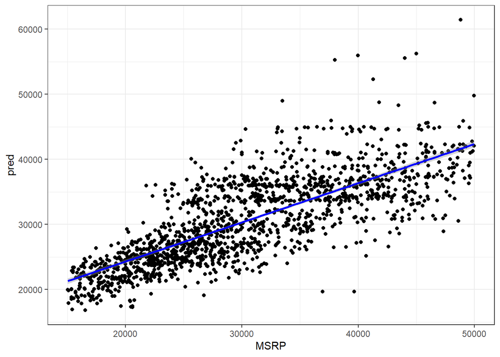

```r
par(mfrow=c(1,1))
ggplot(test, aes(x=MSRP, y=pred))+
  geom_point()+
  geom_smooth(method="lm", color="blue")+
  theme_bw()
```

on teh x axis you can see the observered MSRP values and on the Y you can see the predictive values. Now we will calculate the error metrics of the linear model.. we will first find the error. which is observed value subtraced from the respective predicted value.

```r
error <- test$pred - test$MSRP
```

we will calc 2 error metrics RMSE is a good measure to see how accurate the model predicts a response. this is a good test for fit, if the main purpose of the model is prediction.

```r
rmse <- sqrt(mean(error^2))
rmse
```

```
## [1] 5371.526
```

```r
mae <- mean(abs(error))
mae
```

```
## [1] 4268.753
```

in rmse, since the errors are squared before they are averaged, the rmse give a relativly high weight to large errors. this means the rse should be more usedful when large errors a particularly undesirable. but from an interpretataion stnadpoint mean absolte error is better.